# R Notebook

data from https://datacatalog.worldbank.org/dataset/health-nutrition-and-population-statistics

‘Health Nutrition and Population Statistics database provides key health, nutrition and population statistics gathered from a variety of international and national sources. Themes include global surgery, health financing, HIV/AIDS, immunization, infectious diseases, medical resources and usage, noncommunicable diseases, nutrition, population dynamics, reproductive health, universal health coverage, and water and sanitation.’

```r
library(tidyverse)
library(ggplot2)
library(knitr)
library(tidyverse)

#ts analysis/metrics
library(tswge)

#forecasting
library(nnfor)
```

```r
d1 <- read.csv('D:/SMU/Datasets/hnp_stats_csv/HNP_StatsCountry.csv')
d2 <- read.csv('D:/SMU/Datasets/hnp_stats_csv/HNP_StatsCountry-Series.csv')
d3 <- read.csv('D:/SMU/Datasets/hnp_stats_csv/HNP_StatsData.csv')
d4 <- read.csv('D:/SMU/Datasets/hnp_stats_csv/HNP_StatsFootNote.csv')
d5 <- read.csv('D:/SMU/Datasets/hnp_stats_csv/HNP_StatsSeries.csv')
d6 <- read.csv('D:/SMU/Datasets/hnp_stats_csv/HNP_StatsSeries-Time.csv')
```

d2 is sources for figures

d3 is the by country/reigon annual time series data by category by year, range varies contains columns for country name matched with category of variable for each country, date ranges start from column 5

example codes for categorical figures - SP.DYN.CBRT.IN is birth rate

d4 is country and category code sources (more?again?)

d5 is more category source codes, with additional notes on source variability/uncertainty

d6 is more codes with notes about interpolation and such

```r
#fix date columns in d3
names(d3) <- c('Country.Name', 'Country.Code', 'Indicator.Name', 'Indicator.Code', seq(1960, 2020, 1), 'x')
```

```r
#select from d3 conditional
temp = d3[d3$Country.Code == 'ARB', ]
d3[d3$Country.Code == 'ARB' & d3$Indicator.Code == 'SP.DYN.CBRT.IN', ]
```

|  | Country.Name | Country.Code | Indicator.Name | Indicator.Code | 1960 | 1961 | 1962 | 1963 | 1964 | 1965 | 1966 | 1967 | 1968 | 1969 | 1970 | 1971 | 1972 | 1973 | 1974 | 1975 | 1976 | 1977 | 1978 | 1979 | 1980 | 1981 | 1982 | 1983 | 1984 | … |
| --- | --- | --- | --- | --- | --- | --- | --- | --- | --- | --- | --- | --- | --- | --- | --- | --- | --- | --- | --- | --- | --- | --- | --- | --- | --- | --- | --- | --- | --- | --- |
| 67 | Arab World | ARB | Birth rate, crude (per 1,000 people) | SP.DYN.CBRT.IN | 47.79008 | 47.55839 | 47.3276 | 47.09162 | 46.84421 | 46.5771 | 46.28291 | 45.96055 | 45.61137 | 45.23716 | 44.84362 | 44.44035 | 44.03865 | 43.64783 | 43.27485 | 42.92493 | 42.60063 | 42.2929 | 41.98993 | 41.68051 | 41.34983 | 40.98353 | 40.57024 | 40.10007 | 39.56784 | … |

goal - select rows by country code and melt/format into per-country dataframes for plotting/comparison

```r
selector <- function(country_code, metric_code){
  temp <- d3[d3$Country.Code == country_code & d3$Indicator.Code == metric_code, ][c(-1:-4)]
  return(unlist(temp))#want only the vector, not years, without unlist temp is dataframe
}
#example input -> selector('ARB', 'SP.DYN.CBRT.IN')
#selector('ARB', 'SP.DYN.CBRT.IN')
```

```r
#selector('ARB', 'SP.DYN.CBRT.IN')
#single metric #birthrate
#temp <- selector('ARB', 'SP.DYN.CBRT.IN')
#plot(x = seq(1960, 2021, 1), y = temp[5:length(temp)])
```

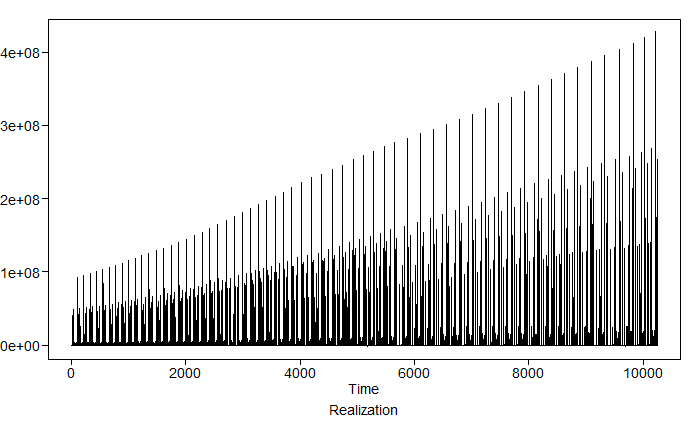

```r
#ts analysis/metrics/characteristics
x <- temp[5:length(temp)]
x <- x[!is.na(x)]
plotts.wge(x)
```

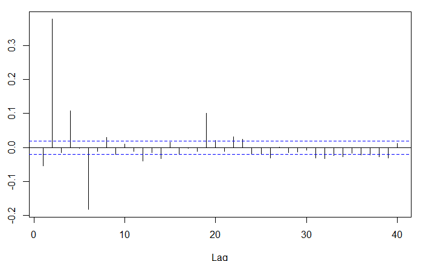

```r
pacf(x)
```

[output not shown]

[output cut: 374 more lines]

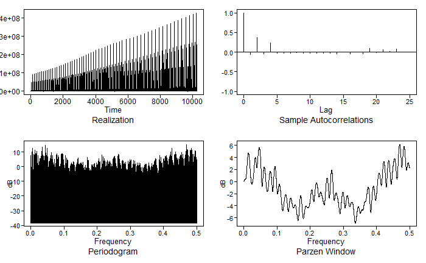

```r
plotts.sample.wge(x)
```

not seasonal, likely no frequency, not suited to time series approach regression?

#testing various forecasting techniques

```r
#put together multiple ts on single frame
ARB <- data.frame(
  year = seq(1960, 2021, 1),
  birth_rate = selector('ARB', 'SP.DYN.CBRT.IN'),
  death_rate = selector('ARB', 'SP.DYN.CDRT.IN'),
  fertility_rate = selector('ARB', 'SP.DYN.TFRT.IN'),
  m_life_expectancy = selector('ARB', 'SP.DYN.LE00.MA.IN'),
  f_life_expectancy = selector('ARB', 'SP.DYN.LE00.FE.IN'),
  t_life_expectancy = selector('ARB', 'SP.DYN.LE00.IN'),
  m_mort_rate = selector('ARB', 'SP.DYN.AMRT.MA'),
  f_mort_rate = selector('ARB', 'SP.DYN.AMRT.FE')
)
ARB <- na.omit(ARB)
ARB_train = ARB[1:50, ]
ARB_test = ARB[51:59, ]
```

```r
#choose from unique(d3$Country.Code)

ts_grabber <- function(cc){
  newframe <- data.frame(
    year = seq(1960, 2021, 1),
    birth_rate = selector(cc, 'SP.DYN.CBRT.IN'),
    death_rate = selector(cc, 'SP.DYN.CDRT.IN'),
    fertility_rate = selector(cc, 'SP.DYN.TFRT.IN'),
    m_life_expectancy = selector(cc, 'SP.DYN.LE00.MA.IN'),
    f_life_expectancy = selector(cc, 'SP.DYN.LE00.FE.IN'),
    t_life_expectancy = selector(cc, 'SP.DYN.LE00.IN'),
    m_mort_rate = selector(cc, 'SP.DYN.AMRT.MA'),
    f_mort_rate = selector(cc, 'SP.DYN.AMRT.FE')
  )
  newframe <- na.omit(newframe)
  return(newframe)
}
#ts_grabber('IRN')
```

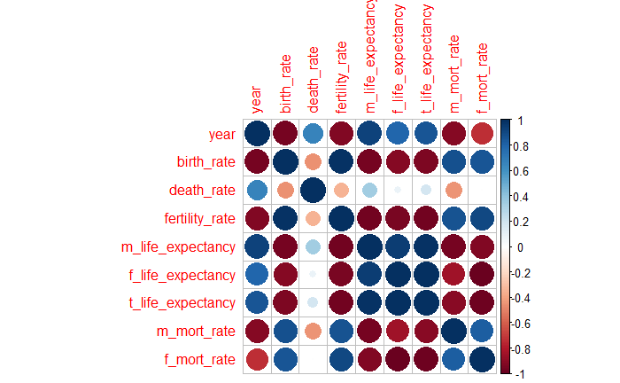

```r
corrplot::corrplot(cor(ts_grabber('MNE')), method = 'circle')
```

#correlation and misc

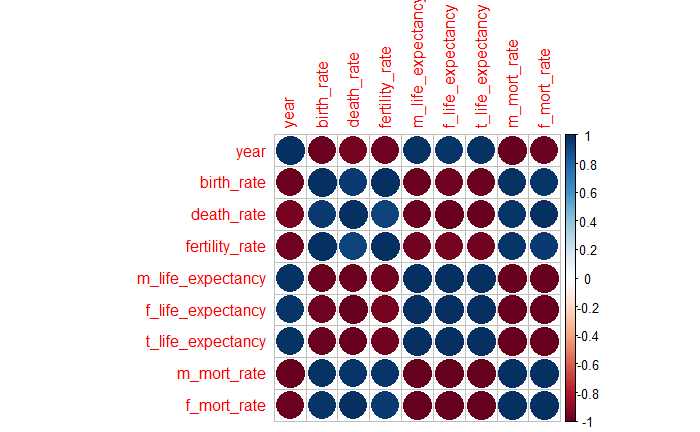

```r
corrplot::corrplot(cor(ARB), method = 'circle')
```

fairly clear correlation, though generalized; since the 1960’s in [this region] life expectancy has gone up and birth, death, fertility, and mortality rates have gone down

#ridge regression and prediction

```r
#ridge regression with glmnet
#uses multiple independent variable to predict single dependent
library(glmnet)
xvar = data.matrix(ARB_train[, c(1, 2, 3, 7, 8)])
yvar = ARB_train$t_life_expectancy
#set lambda values
lambda_seq <- 10^seq(2, -2, by = -.1)
#build ridge regression
fit <- glmnet(xvar, yvar, alpha = 0, lambda  = lambda_seq)
summary(fit) #not sure what to make of this part yet
```

```
          Length Class     Mode
a0         41    -none-    numeric
beta      205    dgCMatrix S4
df         41    -none-    numeric
dim         2    -none-    numeric
lambda     41    -none-    numeric
dev.ratio  41    -none-    numeric
nulldev     1    -none-    numeric
npasses     1    -none-    numeric
jerr        1    -none-    numeric
offset      1    -none-    logical
call        5    -none-    call
nobs        1    -none-    numeric
```

```r
# Using cross validation glmnet, find 'best' lambda value
ridge_cv <- cv.glmnet(xvar, yvar, alpha = 0, lambda = lambda_seq)
# Best lambda value
best_lambda <- ridge_cv$lambda.min
best_lambda
```

```
[1] 0.01
```

```r
#this part is a manual? way of looking at the 'best' lambda value? want to pick the lambda that corresponds to the highest dev.ratio, as the previous cell determines, the highest dev.ratio matches lambda = 0.01

best_fit <- ridge_cv$glmnet.fit
head(best_fit)
```

```
$a0
         s0          s1          s2          s3          s4          s5          s6          s7          s8
   7.472913   -1.853333  -11.998077  -22.774799  -33.932050  -45.178223  -56.198447  -66.719937  -76.485646
         s9         s10         s11         s12         s13         s14         s15         s16         s17
 -85.307118  -93.054616  -99.696271 -105.203744 -109.486198 -112.788745 -115.079063 -116.277726 -116.837552
        s18         s19         s20         s21         s22         s23         s24         s25         s26
-116.627920 -115.733761 -114.273063 -112.109216 -109.676861 -106.746812 -103.716120 -100.444744  -97.386320
        s27         s28         s29         s30         s31         s32         s33         s34         s35
 -95.664199  -90.825237  -89.871563  -88.386289  -84.765904  -84.599893  -83.840002  -83.370886  -83.449601
        s36         s37         s38         s39         s40
 -84.345951  -85.414179  -87.124978  -88.986207  -91.059081

$beta
5 x 41 sparse Matrix of class "dgCMatrix"
```

[output not shown]

[output not shown]

```r
#using best lambda value,  build ridge regression model, get coefficients
best.ridge = glmnet(xvar, yvar, alpha = 0, lambda = 0.01)
coef(best.ridge)
```

```
6 x 1 sparse Matrix of class "dgCMatrix"
                             s0
(Intercept)       -92.950456532
year                0.068332464
birth_rate         -0.106399798
death_rate         -0.566766692
t_life_expectancy   0.446453706
m_mort_rate         0.003144495
```

```r
#prediction
pred <- predict(best.ridge, s = best_lambda, newx = data.matrix(ARB_test[, c(1, 2, 3, 7, 8)]))
#looks like data for ridge regression has to be in datamatrix form?
actual <- ARB$t_life_expectancy[51:59]

rss <- sum((pred - actual) ^ 2)
tss <- sum((actual - mean(actual)) ^ 2)
rsq <- 1 - rss/tss
rsq
```

```
[1] 0.9181831
```

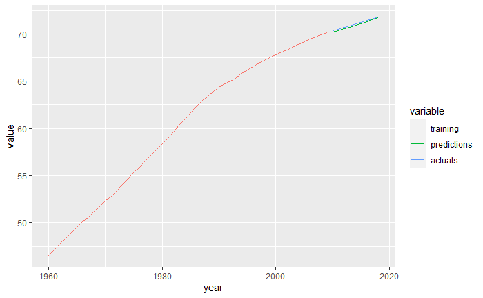

```r
#vis
library(ggplot2)
library(reshape2)
#better way to space this out automatically, later
m1 <- data.frame(training = c(ARB_train$t_life_expectancy, rep(NA, 9)), predictions = c(rep(NA, 50), pred), actuals = c(rep(NA, 50), actual), year = ARB$year)

m1 <- melt(m1, id = 'year')

ggplot(m1) + geom_line(aes(x = year, y = value, col = variable))
```

ok, for a simple example that’s not too bad

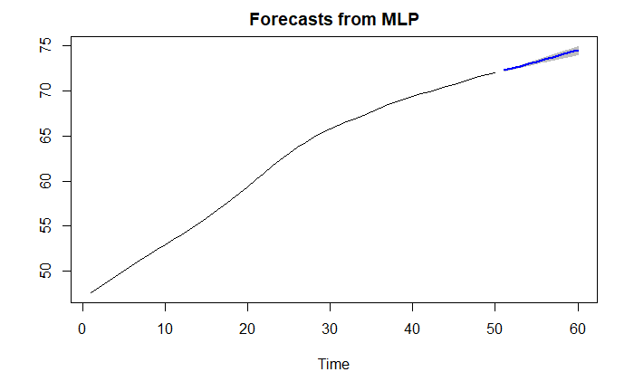

```r
#predictions with nnfor
library(nnfor)

#ts1 <- ts(ARB_train$t_life_expectancy, start(1960), freq = 1)
ts1 <- ts(ARB_train[, 6])
#mlp on sea data alone, reserve last 36 entries for endpoint ase
mlp_fit = mlp(ts1 ,reps = 40, comb = "mean") #only takes single ts
mlp_fore = forecast(mlp_fit, h = 10, bootstrap = TRUE) #forecast 36 ~about 1 year ahead
plot(mlp_fore)
```

```r
#library(ggplotgui)
#ggplot_shiny(ARB)
```